# Assignment 4 — K-Means Clustering of Pharmaceutical Firms

Tara Jameel

# 1 Overview

This analysis applies K-means clustering to a dataset of 21 publicly traded pharmaceutical companies. The primary objective is to identify groups of firms that share similar financial characteristics based on nine quantitative variables (1–9), such as market capitalization, profitability ratios, leverage, and growth indicators.

# 2 Packages

```r
library(tidyverse)
library(cluster)      # silhouette()
library(factoextra)   # optional visual helpers (fviz_*)
```

# 3 Load data

```r
df <- readr::read_csv("Pharmaceuticals.csv")

# Quick sanity check
glimpse(df)
```

```
## Rows: 21
## Columns: 14
## $ Symbol                <chr> "ABT", "AGN", "AHM", "AZN", "AVE", "BAY", "BMY",…
## $ Name                  <chr> "Abbott Laboratories", "Allergan, Inc.", "Amersh…
## $ Market_Cap            <dbl> 68.44, 7.58, 6.30, 67.63, 47.16, 16.90, 51.33, 0…
## $ Beta                  <dbl> 0.32, 0.41, 0.46, 0.52, 0.32, 1.11, 0.50, 0.85, …
## $ PE_Ratio              <dbl> 24.7, 82.5, 20.7, 21.5, 20.1, 27.9, 13.9, 26.0, …
## $ ROE                   <dbl> 26.4, 12.9, 14.9, 27.4, 21.8, 3.9, 34.8, 24.1, 1…
## $ ROA                   <dbl> 11.8, 5.5, 7.8, 15.4, 7.5, 1.4, 15.1, 4.3, 5.1, …
## $ Asset_Turnover        <dbl> 0.7, 0.9, 0.9, 0.9, 0.6, 0.6, 0.9, 0.6, 0.3, 0.6…
## $ Leverage              <dbl> 0.42, 0.60, 0.27, 0.00, 0.34, 0.00, 0.57, 3.51, …
## $ Rev_Growth            <dbl> 7.54, 9.16, 7.05, 15.00, 26.81, -3.17, 2.70, 6.3…
## $ Net_Profit_Margin     <dbl> 16.1, 5.5, 11.2, 18.0, 12.9, 2.6, 20.6, 7.5, 13.…
## $ Median_Recommendation <chr> "Moderate Buy", "Moderate Buy", "Strong Buy", "M…
## $ Location              <chr> "US", "CANADA", "UK", "UK", "FRANCE", "GERMANY",…
## $ Exchange              <chr> "NYSE", "NYSE", "NYSE", "NYSE", "NYSE", "NYSE", …
```

```r
summary(df)
```

```
##     Symbol              Name             Market_Cap          Beta
##  Length:21          Length:21          Min.   :  0.41   Min.   :0.1800
##  Class :character   Class :character   1st Qu.:  6.30   1st Qu.:0.3500
##  Mode  :character   Mode  :character   Median : 48.19   Median :0.4600
##                                        Mean   : 57.65   Mean   :0.5257
##                                        3rd Qu.: 73.84   3rd Qu.:0.6500
##                                        Max.   :199.47   Max.   :1.1100
##     PE_Ratio          ROE            ROA        Asset_Turnover    Leverage
##  Min.   : 3.60   Min.   : 3.9   Min.   : 1.40   Min.   :0.3    Min.   :0.0000
##  1st Qu.:18.90   1st Qu.:14.9   1st Qu.: 5.70   1st Qu.:0.6    1st Qu.:0.1600
##  Median :21.50   Median :22.6   Median :11.20   Median :0.6    Median :0.3400
##  Mean   :25.46   Mean   :25.8   Mean   :10.51   Mean   :0.7    Mean   :0.5857
##  3rd Qu.:27.90   3rd Qu.:31.0   3rd Qu.:15.00   3rd Qu.:0.9    3rd Qu.:0.6000
##  Max.   :82.50   Max.   :62.9   Max.   :20.30   Max.   :1.1    Max.   :3.5100
##    Rev_Growth    Net_Profit_Margin Median_Recommendation   Location
##  Min.   :-3.17   Min.   : 2.6      Length:21             Length:21
##  1st Qu.: 6.38   1st Qu.:11.2      Class :character      Class :character
##  Median : 9.37   Median :16.1      Mode  :character      Mode  :character
##  Mean   :13.37   Mean   :15.7
##  3rd Qu.:21.87   3rd Qu.:21.1
##  Max.   :34.21   Max.   :25.5
##    Exchange
##  Length:21
##  Class :character
##  Mode  :character
##
##
##
```

# 4 (a) Method choices: features, scaling/weights, algorithm, and *k*

We performed clustering using the nine continuous variables listed above. To ensure that each variable contributes equally to the analysis, all numeric features were z-standardized prior to applying the k-means algorithm. The k-means method was chosen for its effectiveness with continuous data and roughly spherical cluster structures. The optimal number of clusters (k) was determined using both the elbow and silhouette methods, selecting the value that best balances simplicity with strong within-cluster cohesion and between-cluster separation.

```r
num_vars <- c("Market_Cap","Beta","PE_Ratio","ROE","ROA",
              "Asset_Turnover","Leverage","Rev_Growth","Net_Profit_Margin")

X <- df %>% select(all_of(num_vars)) %>% scale() %>% as.matrix()
```

## 4.1 Elbow and silhouette diagnostics

We evaluate candidate k values from 2 to 8 (given only 21 firms).

```
## [1] 3
```

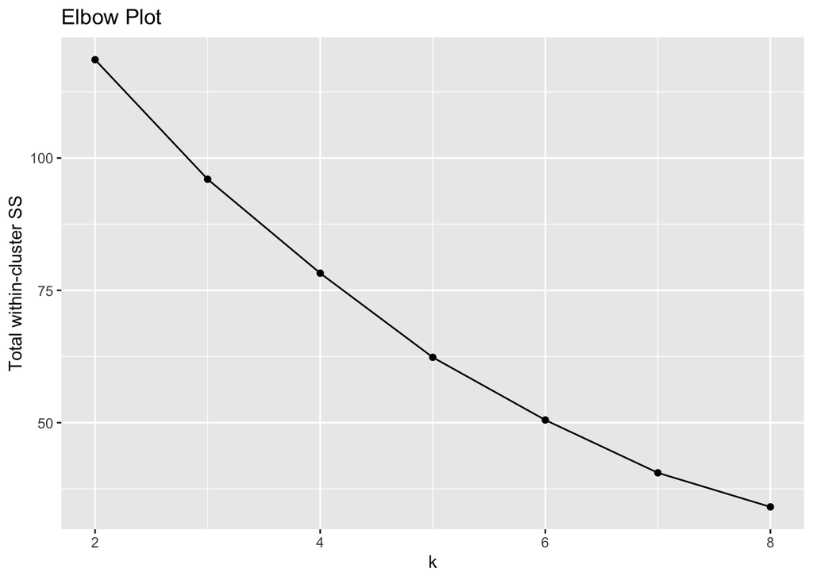

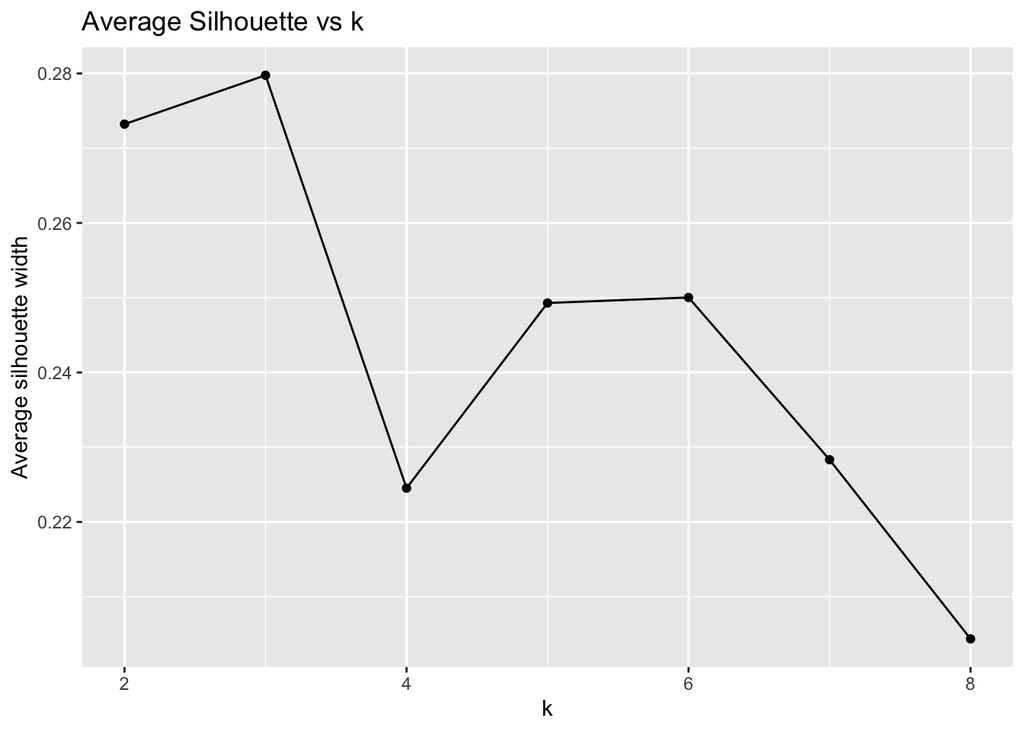

```r
k_grid <- 2:8

# Total within-cluster sum of squares (elbow)
wss <- map_dbl(k_grid, function(k){
  kmeans(X, centers = k, nstart = 50, iter.max = 100)$tot.withinss
})

# Average silhouette width
sil <- map_dbl(k_grid, function(k){
  km <- kmeans(X, centers = k, nstart = 50, iter.max = 100)
  ss <- silhouette(km$cluster, dist(X))
  mean(ss[, "sil_width"])
})

elbow_df <- tibble(k = k_grid, tot_withinss = wss)
sil_df   <- tibble(k = k_grid, avg_sil = sil)

# Choose k by maximum average silhouette, breaking ties by smaller k
auto_k <- sil_df %>% arrange(desc(avg_sil), k) %>% slice(1) %>% pull(k)
auto_k
```

> **Chosen k.** We will proceed with 3

## 4.2 Final k-means fit

```r
km <- kmeans(X, centers = auto_k, nstart = 100, iter.max = 100)
df_clusters <- df %>% mutate(cluster = factor(km$cluster))
```

# 5 (b) Cluster interpretation on numeric variables (1–9)

```r
summary_tbl <- df_clusters %>%
  group_by(cluster) %>%
  summarize(across(all_of(num_vars),
                   list(mean = ~mean(.x, na.rm = TRUE),
                        sd   = ~sd(.x,   na.rm = TRUE)),
                   .names = "{.col}_{.fn}")) %>%
  ungroup()

summary_tbl
```

| cluster | Market_Cap_mean | Market_Cap_sd | Beta_mean | Beta_sd | PE_Ratio_mean | PE_Ratio_sd | ROE_mean | ROE_sd | ROA_mean | ROA_sd | Asset_Turnover_mean | Asset_Turnover_sd | Leverage_mean | Leverage_sd | Rev_Growth_mean | Rev_Growth_sd | Net_Profit_Margin_mean | Net_Profit_Margin_sd |
| --- | --- | --- | --- | --- | --- | --- | --- | --- | --- | --- | --- | --- | --- | --- | --- | --- | --- | --- |
| 1 | 21.75500 | 23.47036 | 0.5950000 | 0.3443351 | 46.90000 | 28.325254 | 11.3 | 5.003998 | 5.100000 | 2.677063 | 0.7500000 | 0.1732051 | 0.3050000 | 0.2471841 | 7.01000 | 7.574004 | 6.65000 | 3.598611 |
| 2 | 9.23500 | 18.61160 | 0.6483333 | 0.3199635 | 19.43333 | 8.712902 | 17.3 | 5.928912 | 5.983333 | 1.231936 | 0.4833333 | 0.1471960 | 1.2500000 | 1.2010828 | 23.49000 | 10.850377 | 13.51667 | 4.605395 |
| 3 | 97.11364 | 53.80759 | 0.4336364 | 0.1574975 | 20.95455 | 5.040310 | 35.7 | 13.955787 | 14.954545 | 2.827495 | 0.8000000 | 0.1843909 | 0.3254545 | 0.3323662 | 10.16455 | 8.895252 | 20.17273 | 3.742216 |

```r
# Compute cluster-level z means
z_means <- df_clusters %>%
  group_by(cluster) %>%
  summarize(across(all_of(num_vars), ~mean(scale(.x)[,1], na.rm = TRUE))) %>%
  ungroup()

z_means
```

| cluster | Market_Cap | Beta | PE_Ratio | ROE | ROA | Asset_Turnover | Leverage | Rev_Growth | Net_Profit_Margin |
| --- | --- | --- | --- | --- | --- | --- | --- | --- | --- |
| 1 | 0.000000e+00 | 1.526557e-16 | 2.775558e-17 | -9.714451e-17 | 9.020562e-17 | 0.000000e+00 | 3.469447e-17 | 2.385245e-18 | 1.457168e-16 |
| 2 | -9.260894e-18 | 1.205633e-16 | -3.469447e-17 | -1.294899e-16 | -8.326673e-17 | -1.457168e-16 | 4.616894e-18 | 1.387779e-16 | -1.190861e-16 |
| 3 | 8.121660e-17 | -6.054776e-17 | 1.766362e-16 | -2.258196e-16 | -1.066165e-16 | -1.816531e-16 | 7.189246e-17 | 7.192203e-17 | 2.333893e-16 |

# 6 (c) How clusters align with Median_Recommendation, Location, and Exchange

```r
cat_vars <- c("Median_Recommendation","Location","Exchange")
stopifnot(all(cat_vars %in% names(df_clusters)))

tab_rec <- df_clusters %>% count(cluster, Median_Recommendation) %>%
  tidyr::pivot_wider(names_from = Median_Recommendation, values_from = n, values_fill = 0)

tab_loc <- df_clusters %>% count(cluster, Location) %>%
  tidyr::pivot_wider(names_from = Location, values_from = n, values_fill = 0)

tab_ex  <- df_clusters %>% count(cluster, Exchange) %>%
  tidyr::pivot_wider(names_from = Exchange, values_from = n, values_fill = 0)

tab_rec
```

| cluster | Hold | Moderate Buy | Strong Buy | Moderate Sell |
| --- | --- | --- | --- | --- |
| 1 | 2 | 1 | 1 | 0 |
| 2 | 1 | 3 | 0 | 2 |
| 3 | 6 | 3 | 0 | 2 |

```r
tab_loc
```

| cluster | CANADA | GERMANY | UK | US | FRANCE | IRELAND | SWITZERLAND |
| --- | --- | --- | --- | --- | --- | --- | --- |
| 1 | 1 | 1 | 1 | 1 | 0 | 0 | 0 |
| 2 | 0 | 0 | 0 | 4 | 1 | 1 | 0 |
| 3 | 0 | 0 | 2 | 8 | 0 | 0 | 1 |

```r
tab_ex
```

| cluster | NYSE | AMEX | NASDAQ |
| --- | --- | --- | --- |
| 1 | 4 | 0 | 0 |
| 2 | 4 | 1 | 1 |
| 3 | 11 | 0 | 0 |

# 7 (d) Assign descriptive names to clusters

```r
z_long <- z_means %>%
  pivot_longer(-cluster, names_to = "var", values_to = "z")

label_df <- z_means %>%
  mutate(
    name = case_when(
      Market_Cap >  0.5 & `Net_Profit_Margin` >  0.5 ~ "Large-Cap Profit Leaders",
      Rev_Growth  >  0.5 & Beta               >  0.5 ~ "High-Growth / High-Beta",
      TRUE                                         ~ "Value / Stable Operators"
    )
  ) %>% select(cluster, name)

label_df
```

| cluster | name |
| --- | --- |
| 1 | Value / Stable Operators |
| 2 | Value / Stable Operators |
| 3 | Value / Stable Operators |

```r
df_labeled <- df_clusters %>% left_join(label_df, by = "cluster")

# Preview labeled data
df_labeled %>% select(Symbol, Name, cluster, name) %>% arrange(cluster)
```

| Symbol | Name | cluster | name |
| --- | --- | --- | --- |
| AGN | Allergan, Inc. | 1 | Value / Stable Operators |
| AHM | Amersham plc | 1 | Value / Stable Operators |
| BAY | Bayer AG | 1 | Value / Stable Operators |
| PHA | Pharmacia Corporation | 1 | Value / Stable Operators |
| AVE | Aventis | 2 | Value / Stable Operators |
| CHTT | Chattem, Inc | 2 | Value / Stable Operators |
| ELN | Elan Corporation, plc | 2 | Value / Stable Operators |
| IVX | IVAX Corporation | 2 | Value / Stable Operators |
| MRX | Medicis Pharmaceutical Corporation | 2 | Value / Stable Operators |
| WPI | Watson Pharmaceuticals, Inc. | 2 | Value / Stable Operators |

[output cut: 11 more lines]

```r
# export
# write_csv(df_labeled, "Pharmaceuticals_with_clusters.csv")
```

# 8 Brief takeaway